# Metodos_kernel_clasificacion_Combita_Niño_Johana

## Tarea01. Métodos kernel para clasificación

Entrega asignatura Machine Learning II

Autor: Johana Cómbita Niño

En esta tarea crearás un clasificador multiclase basado en una SVM para el dataset "Customer IT Support - Ticket Dataset" (https://www.kaggle.com/datasets/tobiasbueck/multilingual-customer-support-tickets).

El dataset consta de 20,000 filas. Cada registro tiene la siguiente estructura (cabecera):

subject, body, answer, type, queue, priority, language, tag_1, tag_2, tag_3, tag_4, tag_5, tag_6, tag_7, tag_8

Para el desarrollo de la tarea, utilizarás únicamente las columnas subject y body (concatenadas en un solo mensaje) como información de entrada, y la columna type como etiqueta de clasificación.

A continuación, se detallan los pasos y apartados que debes desarrollar:

### Exploración

o Carga el dataset ("dataset-tickets-multi-lang-4-20k.csv") y visualiza algunas filas para conocer su estructura y contenido.

o Realiza un análisis descriptivo de las variables, por ejemplo: distribución de la variable type, longitud de los mensajes resultantes de la concatenación de subject y body, etc.

o Comenta cualquier aspecto relevante o posibles problemas, como datos faltantes o inconsistencias.

```python
import numpy as np
import pandas as pd
import matplotlib.pyplot as plt
from sklearn import svm
from sklearn.svm import SVC
from sklearn.decomposition import KernelPCA
import plotly.graph_objs as go
from plotly.offline import iplot
from sklearn.metrics import confusion_matrix
import seaborn as sns
from sklearn.manifold import TSNE
from sklearn.model_selection import train_test_split
import time
from wordcloud import WordCloud
from sklearn.ensemble import RandomForestClassifier

%matplotlib inline
```

Primero se carga el dataset y se visualiza algunas filas para conocer su estructura.

```python
# carga de dataset
dataset = pd.read_csv('dataset-tickets-multi-lang-4-20k.csv', encoding='utf-8', sep=',')

print(dataset.head())
```

```
                                             subject  \
0  Unvorhergesehener Absturz der Datenanalyse-Pla...
1                           Customer Support Inquiry
2                      Data Analytics for Investment
3                 Krankenhaus-Dienstleistung-Problem
4                                           Security

                                                body  \
0  Die Datenanalyse-Plattform brach unerwartet ab...
1  Seeking information on digital strategies that...
2  I am contacting you to request information on ...
3  Ein Medien-Daten-Sperrverhalten trat aufgrund ...
4  Dear Customer Support, I am reaching out to in...

                                              answer      type  \
```

[output cut: 19 more lines]

En el print anterior no es posible visualizar todas las columnas y la información del dataset, por lo cual se puede hacer de esta manera:

```python
#vista completa de 5 filas y todas las columnas
dataset[:5]
```

|  | subject | body | answer | type | queue | priority | language | tag_1 | tag_2 | tag_3 | tag_4 | tag_5 | tag_6 | tag_7 | tag_8 |
| --- | --- | --- | --- | --- | --- | --- | --- | --- | --- | --- | --- | --- | --- | --- | --- |
| 0 | Unvorhergesehener Absturz der Datenanalyse-Pla... | Die Datenanalyse-Plattform brach unerwartet ab... | Ich werde Ihnen bei der Lösung des Problems he... | Incident | General Inquiry | low | de | Crash | Technical | Bug | Hardware | Resolution | Outage | Documentation | NaN |
| 1 | Customer Support Inquiry | Seeking information on digital strategies that... | We offer a variety of digital strategies and s... | Request | Customer Service | medium | en | Feedback | Sales | IT | Tech Support | NaN | NaN | NaN | NaN |
| 2 | Data Analytics for Investment | I am contacting you to request information on ... | I am here to assist you with data analytics to... | Request | Customer Service | medium | en | Technical | Product | Guidance | Documentation | Performance | Feature | NaN | NaN |
| 3 | Krankenhaus-Dienstleistung-Problem | Ein Medien-Daten-Sperrverhalten trat aufgrund ... | Zurück zur E-Mail-Beschwerde über den Sperrver... | Incident | Customer Service | high | de | Security | Breach | Login | Maintenance | Incident | Resolution | Feedback | NaN |
| 4 | Security | Dear Customer Support, I am reaching out to in... | Dear [name], we take the security of medical d... | Request | Customer Service | medium | en | Security | Customer | Compliance | Breach | Documentation | Guidance | NaN | NaN |

En esta primera visualización se observa que se trata de un dataset de tickets, donde se especifica información y características de la solicitud, como el tema, cuerpo del mensaje, respuesta, tipo de solicitud, cola, prioridad, idioma, entre otros.

Ahora miremos que columnas tiene el dataset, tipo de datos y valores nulos.

```python
#información del dataset sobre columnas, valores no nulos y tipo de datos
dataset.info()
valores_nulos = dataset.isnull().sum()
print(valores_nulos[valores_nulos > 0])
```

```
<class 'pandas.core.frame.DataFrame'>
RangeIndex: 20000 entries, 0 to 19999
Data columns (total 15 columns):
 #   Column    Non-Null Count  Dtype
---  ------    --------------  -----
 0   subject   18539 non-null  object
 1   body      19998 non-null  object
 2   answer    19996 non-null  object
 3   type      20000 non-null  object
 4   queue     20000 non-null  object
 5   priority  20000 non-null  object
 6   language  20000 non-null  object
 7   tag_1     20000 non-null  object
 8   tag_2     19954 non-null  object
 9   tag_3     19905 non-null  object
 10  tag_4     18461 non-null  object
 11  tag_5     13091 non-null  object
 12  tag_6     7351 non-null   object
 13  tag_7     3928 non-null   object
 14  tag_8     1907 non-null   object
dtypes: object(15)
memory usage: 2.3+ MB
subject     1461
body           2
answer         4
tag_2         46
tag_3         95
tag_4       1539
tag_5       6909
tag_6      12649
tag_7      16072
tag_8      18093
dtype: int64
```

En esta salida se observan los nombres de las columnas y la cantidad de valores no nulos por cada una de ellas. Se esperaría un valor de 20.000 para cada una, pero como es menor se interpreta que existen valores nulos. Las columnas tag, presentan una mayor cantidad de nulos, al igual que subject (1461). Es de esperarse este comportamiento del subject debido a que hay personas que envían correos o mensajes sin asunto. También, se observan pocos nulos en body (2) y answer (4).

Teniendo en cuenta que, para el análisis a realizar se usará la información de subject y body en una sola columna, para conservar los registros y poder hacer una concatenación que conserve los valores si encuentra nulos, se reemplazan los valores nulos de subject y body por cadenas vacías. Recordemos que subject tiene varios valores nulos que, si concatenamos con body, el resultado será nuevamente una celda de mensaje nulo, haciendo que se pierda la información que tiene body sobre ese mensaje. De igual forma pasa con body.

```python
# Reemplazando valores nulos en subject y body por cadenas vacías
dataset['subject'] = dataset['subject'].fillna('')
dataset['body'] = dataset['body'].fillna('')
```

```python
dataset.info()
```

```
<class 'pandas.core.frame.DataFrame'>
RangeIndex: 20000 entries, 0 to 19999
Data columns (total 15 columns):
 #   Column    Non-Null Count  Dtype
---  ------    --------------  -----
 0   subject   20000 non-null  object
 1   body      20000 non-null  object
 2   answer    19996 non-null  object
 3   type      20000 non-null  object
 4   queue     20000 non-null  object
 5   priority  20000 non-null  object
 6   language  20000 non-null  object
 7   tag_1     20000 non-null  object
 8   tag_2     19954 non-null  object
 9   tag_3     19905 non-null  object
 10  tag_4     18461 non-null  object
 11  tag_5     13091 non-null  object
 12  tag_6     7351 non-null   object
 13  tag_7     3928 non-null   object
 14  tag_8     1907 non-null   object
dtypes: object(15)
memory usage: 2.3+ MB
```

Subject, body y type contienen 20000 registros no nulos.

Ahora vamos a definir el dataframe de análisis solo con subject y body (concatenados) y type como etiqueta. Luego analizamos estas variables.

```python
# Crear una nueva columna 'message' concatenando 'subject' y 'body'
dataset['message'] = dataset['subject'] + ' ' + dataset['body']

#filtrando solo columnas message y type
df = dataset[['message', 'type']]
df[:5]
```

|  | message | type |
| --- | --- | --- |
| 0 | Unvorhergesehener Absturz der Datenanalyse-Pla... | Incident |
| 1 | Customer Support Inquiry Seeking information o... | Request |
| 2 | Data Analytics for Investment I am contacting ... | Request |
| 3 | Krankenhaus-Dienstleistung-Problem Ein Medien-... | Incident |
| 4 | Security Dear Customer Support, I am reaching ... | Request |

```python
# análisis descriptivo de las variables
#distribución de la variable type
type_counts = df['type'].value_counts()
print(type_counts)
#porcentaje de la distribución de la variable type
type_counts / type_counts.sum() * 100
```

```
type
Incident    7978
Request     5763
Problem     4184
Change      2075
Name: count, dtype: int64
```

```
type
Incident    39.890
Request     28.815
Problem     20.920
Change      10.375
Name: count, dtype: float64
```

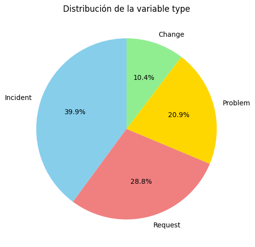

```python
# Gráfico de torta
plt.figure(figsize=(6, 6))
plt.pie(type_counts, labels=type_counts.index, autopct='%1.1f%%', startangle=90, colors=['skyblue', 'lightcoral', 'gold', 'lightgreen'])

plt.title('Distribución de la variable type')
plt.show()
```

Para el caso de type, se observa que tiene 4 categorías, donde aproximadamente el 40% de las solicitudes corresponden a Incidentes, 29% a Solicitudes, 21% a Problemas y 10% a Cambios.

En cuanto al mensaje, es posible analizar su longitud:

```python
#longitud de cada mensaje
df.loc[:, 'length'] = df['message'].apply(len)

#estadísticas descriptivas de la longitud de los mensajes
df['length'].describe()
```

```
count    20000.000000
mean       437.032700
std        250.291682
min          5.000000
25%        241.000000
50%        401.000000
75%        595.000000
max       2284.000000
Name: length, dtype: float64
```

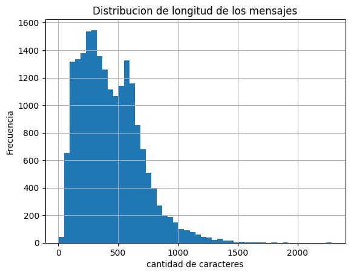

```python
#distribución de length
df['length'].hist(bins=50)
plt.xlabel('cantidad de caracteres')
plt.ylabel('Frecuencia')
plt.title('Distribucion de longitud de los mensajes')
plt.show()
```

A partir de los resultados estadísticos obtenidos de la longitud de los mensajes es posible analizar algunos aspectos. Primero se observa que la longitud promedio de los mensajes es 437 caracteres con una desviación estándar de 250 caracteres aproximadamente (dispersión de longitud), el cual se podría considerar moderada. Es interesante observar que la longitud mínima es de 5 caracteres y la máxima de 2284, siendo bastante amplia. Adicionalmente, se observa que la mediana es cercana a la media con 401 caracteres. Con la longitud mínima se confirma que todas las 20mil filas tienen información y no hay valores nulos o vacíos dada la limpieza anterior.

En la gráfica se observa la distribución de la cantidad de caracteres, validando la información estadística mencionada anteriormente.

Es importante mencionar que este conteo de caracteres incluye letras, números, espacios, signos de puntuación.

Ahora bien, es posible hacer un análisis por palabras, teniendo en cuenta que el conteo mínimo de caracteres fue de 5, siendo interesante identificar ese registro pequeño, si hay más y como es la estructura de estos registros.

```python
# Calcular el número de palabras en cada mensaje
df.loc[:, 'word_count'] = df['message'].apply(lambda x: len(x.split()))

# Obtener estadísticas descriptivas de la cantidad de palabras
df['word_count'].describe()
```

```
count    20000.00000
mean        62.16330
std         36.82158
min          1.00000
25%         33.00000
50%         57.00000
75%         87.00000
max        283.00000
Name: word_count, dtype: float64
```

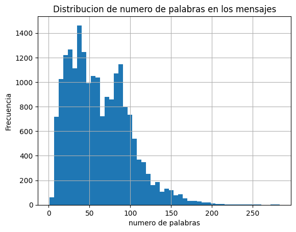

```python
#distribución de word count
df['word_count'].hist(bins=50)
plt.xlabel('numero de palabras')
plt.ylabel('Frecuencia')
plt.title('Distribucion de numero de palabras en los mensajes')
plt.show()
```

Los resultados de estadísticos por palabras muestran que en promedio los mensajes tienen 62 palabras, una desviación estándar de 36 y una mediana de 57 (cercana a la media). De igual forma, se observa que hay una diferencia amplia entre el valor min y max, con 1 y 283 palabras respectivamente. En el histograma es posible ver la frecuencia por número de palabras, evidenciando un comportamiento similar al observado en la cantidad de caracteres.

Observemos la estructura de los mensajes que tienen pocas palabras y caracteres para saber si son los mismos mensajes y que estructura tienen.

```python
#estructura de mensajes con menos de 5 palabras
df[df['word_count'] < 5]
```

|  | message | type | length | word_count |
| --- | --- | --- | --- | --- |
| 485 | Hello support team | Change | 19 | 3 |
| 549 | Help | Request | 5 | 1 |
| 1821 | Probleme bei der Software-Integration | Problem | 38 | 4 |
| 4145 | Support needed | Incident | 15 | 2 |
| 6284 | Seek assistance with billing | Problem | 29 | 4 |
| 6548 | Problems with Software Integration | Problem | 35 | 4 |
| 9033 | SynchronisationProjekttermineNichtRichtig ImAu... | Incident | 260 | 3 |
| 12193 | Can you assist me? | Incident | 19 | 4 |
| 15988 | Error with Tracking Tools | Incident | 26 | 4 |
| 16592 | IT-Consulting authorized access detected | Incident | 40 | 4 |
| 17796 | ConcernregardingSystemInvestmentAnalytics Thec... | Incident | 119 | 2 |
| 18760 | Seeking assistance with billing | Problem | 32 | 4 |

```python
#estructura de mensajes con menos de 40 caracteres
df[df['length'] < 40]
```

|  | message | type | length | word_count |
| --- | --- | --- | --- | --- |
| 485 | Hello support team | Change | 19 | 3 |
| 549 | Help | Request | 5 | 1 |
| 1821 | Probleme bei der Software-Integration | Problem | 38 | 4 |
| 4145 | Support needed | Incident | 15 | 2 |
| 6284 | Seek assistance with billing | Problem | 29 | 4 |
| 6548 | Problems with Software Integration | Problem | 35 | 4 |
| 12193 | Can you assist me? | Incident | 19 | 4 |
| 15988 | Error with Tracking Tools | Incident | 26 | 4 |
| 16763 | Support needed for billing concern | Incident | 35 | 5 |
| 16896 | Please update the marketing campaigns | Change | 38 | 5 |
| 18760 | Seeking assistance with billing | Problem | 32 | 4 |

En términos generales vemos que algunos mensajes con pocas palabras o caracteres no proporcionan mucha información para poder definir claramente el tipo, sin embargo, algunas palabras pueden ser clave para la clasificación, como es el caso de "problem" de tipo Problem, o la palabra "help" para un Request, entre otras. Por tal razon se mantienen para hacer un análisis de todo el dataset.

Por otra parte, se observa una inconsistencia en algunos mensajes, donde las palabras se encuentran pegadas e inician en mayúscula, o separadas por un "guion", mostrado un conteo de palabras menor y una mayor cantidad de caracteres. Esto hace que los mensajes con pocas palabras no sean los mismos que los mensajes con pocos caracteres (en algunos casos).

Adicionalmente, podría considerarse como un desafío o aspecto importante que el dataset tiene mensajes en varios idiomas.

Finalmente, lo importante a identificar en esta exploración de datos es que no tenemos mensajes vacíos, que era lo que se buscaba al conservar los textos al concatenar. Ahora bien, algunos mensajes tienen poca información, pero con alguna palabra clave. Sin embargo, en su mayoría contamos con un dataset con información para el entrenamiento del modelo. Con el modelo que se va a construir se validará si es suficiente para poder clasificar los tickets.

Tambien, es posible identificar palabras claves por categoría. Observemos una nube de palabras para cada clase.

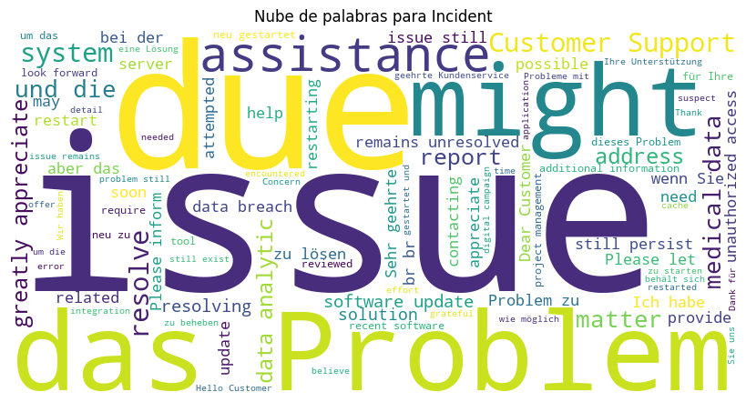

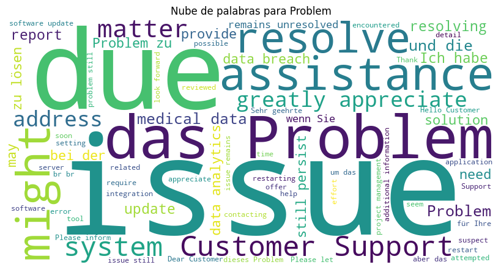

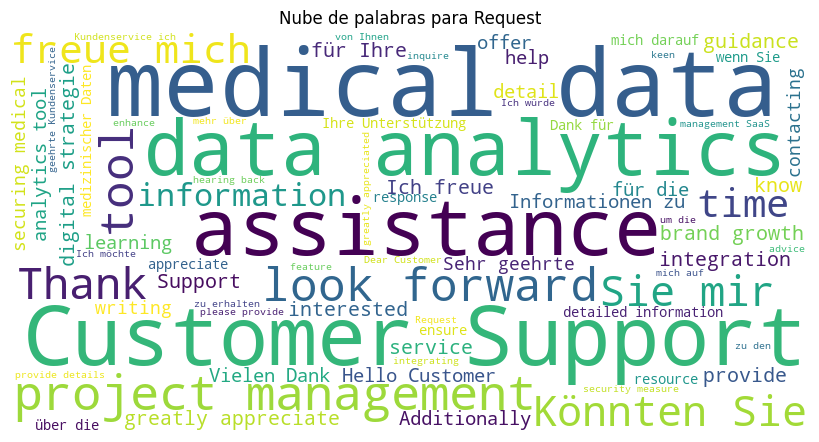

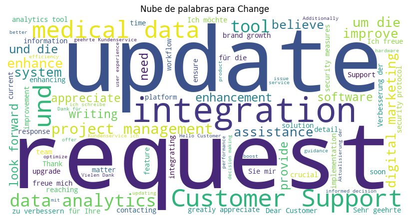

```python
# Nube de palabras para "incident"
incident_tickets = df[df['type'] == 'Incident']['message'].values
if len(incident_tickets) > 0:
    incident = incident_tickets.tolist()
    incident = ' '.join(incident)

    wordcloud_i = WordCloud(width=800, height=400, background_color='white', stopwords=None, min_font_size=10).generate(incident)

    plt.figure(figsize=(8, 8), facecolor=None)
    plt.imshow(wordcloud_i)
    plt.axis("off")
    plt.title('Nube de palabras para Incident')
    plt.tight_layout(pad=0)
    plt.show()

# Nube de palabras para "Problem"
problem_tickets = df[df['type'] == 'Problem']['message'].values
if len(problem_tickets) > 0:
    problem = problem_tickets.tolist()
    problem = ' '.join(problem)

    wordcloud_p = WordCloud(width=800, height=400, background_color='white', stopwords=None, min_font_size=10).generate(problem)

    plt.figure(figsize=(8, 8), facecolor=None)
    plt.imshow(wordcloud_p)
    plt.axis("off")
    plt.tight_layout(pad=0)
    plt.title('Nube de palabras para Problem')
    plt.show()


# Nube de palabras para "Request"
request_tickets = df[df['type'] == 'Request']['message'].values
if len(request_tickets) > 0:
    request = request_tickets.tolist()
    request = ' '.join(request)

    wordcloud_r = WordCloud(width=800, height=400, background_color='white', stopwords=None, min_font_size=10).generate(request)

    plt.figure(figsize=(8, 8), facecolor=None)
    plt.imshow(wordcloud_r)
    plt.axis("off")
    plt.tight_layout(pad=0)
    plt.title('Nube de palabras para Request')
    plt.show()

# Nube de palabras para "Change"
change_tickets = df[df['type'] == 'Change']['message'].values
if len(change_tickets) > 0:
    change = change_tickets.tolist()
    change = ' '.join(change)

    wordcloud_c = WordCloud(width=800, height=400, background_color='white', stopwords=None, min_font_size=10).generate(change)

    plt.figure(figsize=(8, 8), facecolor=None)
    plt.imshow(wordcloud_c)
    plt.axis("off")
    plt.tight_layout(pad=0)
    plt.title('Nube de palabras para Change')
    plt.show()
```

En la nube de palabras se observa que para la clase Incident es comun encontrar palabras como Issue, Problem, Dar, Due, Assistance y might; para Problem palabras como Issue, Problem, Due, Assistance, Das; para Request están data, analytics, custumer, support, medical, assistance, project, management; y Change están las palabras update, request, integration.

A primera vista se observa un mayor equilibrio y variabilidad de las palabras en Request. Por otro lado, en los mensajes de Change, Incident y Problem, resaltan más unas palabras en específico. Además, es importante observar que las palabras más recurrentes en Incident son las mismas que Problem, donde dos de ellas son en Alemán. En el desarrollo del análisis se revisará si esto representa un aspecto importante a la hora de entrenar el modelo y predecir las clases.

Finalmente, hacemos este último análisis de los datos, donde observa que el valor promedio de palabras, mínimo y máximo es similar por cada tipo de mensaje (etiquetas):

```python
#cantidad de palabras promedio por tipo de mensaje
palabras_tipo = df.groupby('type')['word_count'].mean()

#cantidad de palabras min y max por tipo de mensaje
p_tipo_min = df.groupby('type')['word_count'].min()
p_tipo_max = df.groupby('type')['word_count'].max()

#todo en un solo dataframe
palabras_tipo = pd.concat([palabras_tipo, p_tipo_min, p_tipo_max], axis=1)
palabras_tipo.columns = ['promedio', 'min', 'max']
print(palabras_tipo)
```

```
           promedio  min  max
type
Change    67.764337    3  247
Incident  60.133617    2  235
Problem   60.119264    4  283
Request   64.440396    1  257
```

```python
#cantidad de caracteres promedio por tipo de mensaje
caracteres_tipo = df.groupby('type')['length'].mean()

#cantidad de caracteres min y max por tipo de mensaje
c_tipo_min = df.groupby('type')['length'].min()
c_tipo_max = df.groupby('type')['length'].max()

#todo en un solo dataframe
caracteres_tipo = pd.concat([caracteres_tipo, c_tipo_min, c_tipo_max], axis=1)
caracteres_tipo.columns = ['promedio', 'min', 'max']
print(caracteres_tipo)
```

```
            promedio  min   max
type
Change    487.886265   19  1809
Incident  421.642768   15  1613
Problem   420.401769   29  2284
Request   452.101857    5  1897
```

### Preprocesamiento

o Concatena las columnas subject y body para formar el mensaje.

o Selecciona una muestra de N=1,000 filas del dataset completo. Deja N como parámetro a modificar.

o Separa el dataset en conjunto de entrenamiento y test, utilizando un 25% de los datos para test.

Teniendo concatenado el subject y body del punto anterior (message), se selecciona una muestra de N = 1000 filas y se crea el conjunto de train (75%) y test (25%).

```python
#Muestra
N = 1000
df_muestra = df.sample(N, random_state=1202)

# Dividir el dataset en conjunto de entrenamiento y prueba
test_size = 0.25
X_train, X_test, y_train, y_test = train_test_split(df_muestra['message'], df_muestra['type'], test_size=test_size, random_state=1202)

print(X_train.shape, X_test.shape, y_train.shape, y_test.shape)
```

```
(750,) (250,) (750,) (250,)
```

```python
# se reinician los índices para poder acceder a ellos. Esto debido a que se obtuvieron de un sample
X_train = X_train.reset_index(drop=True)
X_test = X_test.reset_index(drop=True)
y_train = y_train.reset_index(drop=True)
y_test = y_test.reset_index(drop=True)
X_train
```

```
0      Support for Customer Enquiries Can you provide...
1      Anforderung für technische Unterstützung Unser...
2      Detailed Information on Scalable Project Manag...
3      Security Protocols for Healthcare Data Managem...
4      Assistance for AI in Hospitals there is a serv...
                             ...
745    Verbesserung der Investitionsdatenanalyse mit ...
746    Support für QuickBooks Online - Data Analytics...
747    Digital Update Inquiry Hello Customer Support,...
748    Elasticsearch für Digitale Marketing Können Si...
749    Support SaaS Platform Issue Our system has bee...
Name: message, Length: 750, dtype: object
```

```python
#tipos de mensajes en el conjunto de entrenamiento para revisar balance de la muestra
y_train.value_counts()
```

```
type
Incident    315
Request     194
Problem     171
Change       70
Name: count, dtype: int64
```

```python
#tipos de mensajes en el conjunto de test
y_test.value_counts()
```

```
type
Incident    102
Request      63
Problem      60
Change       25
Name: count, dtype: int64
```

### Implementación del string kernel

o Implementa un kernel que, para dos cadenas, cuente el número de trigramas (subcadenas de longitud 3) comunes, tal y como se ha visto en la clase de teoría.

```python
#definición de kernel string - triagramas
def triagram_kernel(string1, string2):
    #mayúsculas a minúsculas
    string1 = string1.lower()
    string2 = string2.lower()
    #quitar tildes
    string1 = string1.replace('á', 'a').replace('é', 'e').replace('í', 'i').replace('ó', 'o').replace('ú', 'u')
    string2 = string2.replace('á', 'a').replace('é', 'e').replace('í', 'i').replace('ó', 'o').replace('ú', 'u')
    #calcular triagramas
    tria1 = set([string1[i:i+3] for i in range(len(string1) - 2)])
    tria2 = set([string2[i:i+3] for i in range(len(string2) - 2)])
    # Calcular la intersección de triagramas
    common = tria1.intersection(tria2)
    return len(common)
```

```python
#Prueba de kernel
p1 = triagram_kernel('holan', 'holanda') # hol, ola, lan -> 3
p2 = triagram_kernel('hola mi nombre es Johana', 'hola mí nombre es johana, mucho gusto')

print(p1, p2)
```

```
3 22
```

### Entrenamiento de la SVM

o Utiliza el kernel implementado para entrenar una SVM sobre el conjunto de entrenamiento.

Para entrenar una SVM se necesita calcular la similitud entre todas las posibles parejas de mensajes en el conjunto de entrenamiento. Esto implica construir una matriz de similitud (matriz kernel) donde cada entrada (i, j) representa la similitud entre el mensaje i y el mensaje j del conjunto de datos.

```python
#kernel matrix
def kernel_matrix(mensajes):
    n = len(mensajes)
    #matriz de ceros
    k_matrix = np.zeros((n, n))
    #calcular kernel para cada par de mensajes
    for i in range(n):
        for j in range(i, n):
            k_matrix[i, j] = triagram_kernel(mensajes[i], mensajes[j])
            k_matrix[j, i] = k_matrix[i, j]
    return k_matrix
```

```python
#prueba
prueba = ['hola', 'holanda', 'hola mundo', 'hola mundo, mucho gusto']

K = kernel_matrix(prueba)
K
```

```
array([[ 2.,  2.,  2.,  2.],
       [ 2.,  5.,  2.,  2.],
       [ 2.,  2.,  8.,  8.],
       [ 2.,  2.,  8., 20.]])
```

Construida la función , calculamos la matriz Kernel para el caso de estudio:

```python
#para train
matriz_kernel = kernel_matrix(X_train)
matriz_kernel
```

```
array([[182.,  41.,  59., ...,  92.,   3.,  38.],
       [ 41., 408.,  25., ..., 105.,  31.,  43.],
       [ 59.,  25.,  94., ...,  51.,   3.,  20.],
       ...,
       [ 92., 105.,  51., ..., 491.,  23.,  78.],
       [  3.,  31.,   3., ...,  23.,  64.,   3.],
       [ 38.,  43.,  20., ...,  78.,   3., 215.]], shape=(750, 750))
```

Luego, entrenamos el modelo sobre el conjunto de entrenamiento con un valor preliminar de C = 1.0 que luego vamos a revisar si se puede optimizar.

```python
svc = SVC(kernel='precomputed', C=1.0)
svc.fit(matriz_kernel, y_train)
```

```
SVC(kernel='precomputed')
```

### Evaluación y Análisis del Modelo

a. Calcula la precisión del clasificador sobre el conjunto de test.

Con el modelo entrenado, primero se calcula la precisión del clasificador sobre el conjunto de test. Para esto se calcula la matriz de kernel para el conjunto de prueba.

```python
#primero se calcula la matriz de kernel para el conjunto de prueba
def kernel_matrix_test(mensajes_train, mensajes_test):
    n_train = len(mensajes_train)
    n_test = len(mensajes_test)
    k_matrix = np.zeros((n_test, n_train))

    for i in range(n_test):
        for j in range(n_train):
            k_matrix[i, j] = triagram_kernel(mensajes_test[i], mensajes_train[j])

    return k_matrix

matriz_kernel_t = kernel_matrix_test(X_train, X_test)
matriz_kernel_t
```

```
array([[ 27.,  25.,  14., ...,  68.,   7.,  49.],
       [ 30., 153.,  13., ...,  89.,  37.,  37.],
       [ 25.,  30.,   8., ...,  44.,   4.,  44.],
       ...,
       [ 29.,  22.,  22., ...,  42.,   3.,  18.],
       [ 32., 137.,  20., ...,  74.,  27.,  39.],
       [ 70.,  72.,  41., ..., 148.,   9., 139.]], shape=(250, 750))
```

Luego se predicen los datos y se calcula el accuracy.

```python
# Predicción
y_pred = svc.predict(matriz_kernel_t)
```

```python
from sklearn.metrics import accuracy_score

accuracy = accuracy_score(y_test, y_pred)

print('Accuracy:', accuracy)
```

```
Accuracy: 0.712
```

También es posible ver el reporte de clasificación que contiene diferentes métricas.

```python
from sklearn.metrics import classification_report

print(classification_report(y_test, y_pred))
```

```
              precision    recall  f1-score   support

      Change       0.87      0.80      0.83        25
    Incident       0.67      0.71      0.69       102
     Problem       0.47      0.45      0.46        60
     Request       0.94      0.94      0.94        63

    accuracy                           0.71       250
   macro avg       0.74      0.72      0.73       250
weighted avg       0.71      0.71      0.71       250
```

En términos generales, este modelo tiene unos buenos resultados para los tipos Request y Change, aceptables para Incident y deficientes para Problem. En este ultimo presenta dificultades en la clasificación.

b. Ajusta los parámetros del clasificador y comenta el efecto sobre la precisión. Prueba valores distintos de N.

Primero se ajusta los parámetros del clasificador. Para este caso, como en el modelo se establece la matriz kernel (con precomputed), el único parámetro a optimizar es C que controla la penalización por errores de clasificación, determinado la dureza del margen. Para esto, se puede ajustar con validación cruzada.

```python
from sklearn.model_selection import GridSearchCV

param_grid = {'C': [0.001, 0.005, 0.01, 0.05, 0.1, 0.5, 1, 10, 50, 100]}

grid = GridSearchCV(SVC(kernel='precomputed'), param_grid, cv=5)
grid.fit(matriz_kernel, y_train)
clf = grid.best_estimator_

#El mejor valor de C
print(grid.best_params_)
```

```
{'C': 0.01}
```

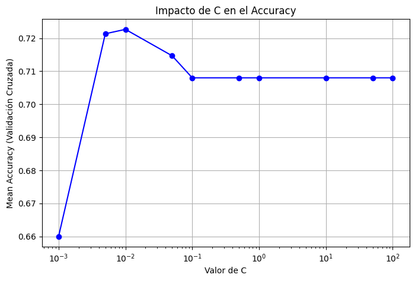

```python
# valores de C probados y sus respectivos scores
C_values = grid.cv_results_['param_C'].data.astype(float)
mean_scores = grid.cv_results_['mean_test_score']  # Accuracy promedio

# Grafica
plt.figure(figsize=(8,5))
plt.plot(C_values, mean_scores, marker='o', linestyle='-', color='b')
plt.xscale('log')
plt.xlabel('Valor de C')
plt.ylabel('Mean Accuracy (Validación Cruzada)')
plt.title('Impacto de C en el Accuracy')
plt.grid(True)
plt.show()
```

En la gráfica se puede observar que a medida que el margen se hace más duro (C más alto) el accuracy aumenta, es decir hay menos error en la clasificación por la alta penalización al error. Luego, se observa que cambios en el valor C no permiten una mejora en el acurracy (se estabiliza).

Valores pequeños de C dan como resultado un margen suave donde hay mucho más error, generando un modelo flexible y evitando el sobre ajuste, pero valores muy pequeños pueden llevar a que el modelo no ajuste a los datos por lo que puede generar valores de accuracy bajos. En la gráfica se observa que el primer valor de C es bastante flexible, y a medida que aumenta nos acercamos al óptimo.

El punto óptimo es el equilibrio que permite el menor error de clasificación y una generalización por parte del modelo para evitar el sobreajuste y subajuste. Para este caso es el valor de C = 0.01.

Con el parámetro C óptimo, probemos diferentes valores de N y como afecta la precisión.

```python
N = [50, 100, 200, 500, 1000, 2000]
test_size = 0.25
c_opt = grid.best_params_['C']

muestras_n = {}
matriz_kernel_n = {}
matriz_kernel_t_n = {}
modelo_svc_n = {}

for n in N:
    star_time = time.time()
    ##Definición de la muestra
    df_muestra_n = df.sample(n, random_state=1202)
    X_train_n, X_test_n, y_train_n, y_test_n = train_test_split(df_muestra_n['message'], df_muestra_n['type'], test_size=test_size, random_state=1202)
    X_train_n = X_train_n.reset_index(drop=True)
    X_test_n = X_test_n.reset_index(drop=True)
    y_train_n = y_train_n.reset_index(drop=True)
    y_test_n = y_test_n.reset_index(drop=True)

    #matriz de kernel para train
    matriz_kernel_n[n] = kernel_matrix(X_train_n)
    matriz_kernel_t_n[n] = kernel_matrix_test(X_train_n, X_test_n)

    #entrenamiento
    modelo_svc = SVC(kernel='precomputed', C=c_opt)
    modelo_svc.fit(matriz_kernel_n[n], y_train_n)

    #predicción
    y_pred_n = modelo_svc.predict(matriz_kernel_t_n[n])

    #accuracy
    accuracy_n = accuracy_score(y_test_n, y_pred_n)
    print('N:', n, 'Accuracy:', accuracy_n)
    #vectores soporte
    print('Vectores soporte:', modelo_svc.n_support_)

    # Guardar resultados
    muestras_n[n] = {
        "y_test": y_test_n,
        "X_test": X_test_n,
        "y_pred": y_pred_n,
        "X_train": X_train_n,
        "y_train": y_train_n,
    }
    #guardar modelo
    modelo_svc_n[n] = modelo_svc

    end_time = time.time()
    print('Tiempo:', end_time - star_time)
```

```
N: 50 Accuracy: 0.7692307692307693
Vectores soporte: [ 5 20  4  8]
Tiempo: 0.2404797077178955
N: 100 Accuracy: 0.72
Vectores soporte: [13 28 16 17]
Tiempo: 0.9595003128051758
N: 200 Accuracy: 0.7
Vectores soporte: [22 53 36 37]
Tiempo: 3.6010515689849854
N: 500 Accuracy: 0.744
Vectores soporte: [ 41 144  85  83]
Tiempo: 20.74507474899292
N: 1000 Accuracy: 0.704
Vectores soporte: [ 67 276 170 143]
Tiempo: 80.507568359375
N: 2000 Accuracy: 0.746
Vectores soporte: [132 454 318 233]
Tiempo: 328.0196294784546
```

Sin embargo, es importante notar que, aunque el número de vectores de soporte aumenta, la precisión (accuracy) no mejora de manera significativa. Aunque se observan pequeños incrementos en el accuracy, no hay un aumento considerable ni un patrón claro de crecimiento o decrecimiento, lo que sugiere que agregar más datos no necesariamente mejora el desempeño del modelo. Esto puede indicar que, después de cierto punto, los datos adicionales no aportan nueva información relevante al modelo. Por su parte, vemos que valores mas grande de N tienen un mayor coste computacional. Se observa como el tiempo de ejecución del modelo va aumentando a medida que incrementa N, partiendo de 0.2 seg con N=50 a 328.01 seg con N=2000.

Considerando el costo computacional y que no hay cambios significativos con un valor alto de N, se tomará para los análisis un tamaño N = 500 con C = 0.01, el cual genera un valor un poco mas alto del accuracy, un tiempo moderado y es un muestra considerable.

c. Realiza un análisis de algunos mensajes que hayan sido mal clasificados: ¿qué características presentan? ¿Qué aspectos podrían haber llevado a la clasificación errónea?

```python
# metricas de N = 500
print(classification_report(muestras_n[500]['y_test'], muestras_n[500]['y_pred']))
```

```
              precision    recall  f1-score   support

      Change       0.90      0.69      0.78        13
    Incident       0.75      0.80      0.78        56
     Problem       0.47      0.36      0.41        25
     Request       0.83      0.97      0.90        31

    accuracy                           0.74       125
   macro avg       0.74      0.71      0.72       125
weighted avg       0.73      0.74      0.73       125
```

En los resultados de este modelo se observa que la clase Problem sigue presentando dificultades para su clasificación, con una precisión inferior al 50%. Por otro lado, el porcentaje de predicciones correctas para la clase Incident mejora, mientras que para las demás clases se mantiene alto.

En cuanto al recall, el modelo muestra poca sensibilidad para identificar correctamente la clase Problem, mientras que mejora en Incident y disminuye en Change. Sin embargo, el F1-Score, que combina precisión y recall, muestra buenos resultados para Incident, Request y Change, y Problem sigue siendo la clase con mayor dificultad de clasificación.

El bajo recall de Change podría estar relacionado con su bajo soporte en los datos de prueba. En el caso de Problem, se requieren más análisis para identificar las razones de sus problemas de clasificación.

Ahora miremos la matriz de confusión para entender un poco más los problemas de clasificación que se están presentando e identificar posibles razones.

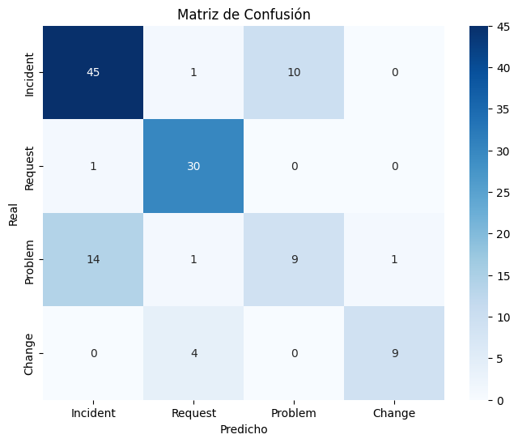

```python
cm = confusion_matrix(muestras_n[500]["y_test"], muestras_n[500]['y_pred'], labels=type_counts.index)
plt.figure(figsize=(8, 6))
sns.heatmap(cm, annot=True, fmt='d', xticklabels=type_counts.index, yticklabels=type_counts.index, cmap='Blues')
plt.xlabel('Predicho')
plt.ylabel('Real')
plt.title('Matriz de Confusión')
plt.show()
```

La matriz de confusión muestra en su diagonal que las clases con mayor precisión son Incident y Request; la clase Change obtiene buenos resultados, considerando su bajo soporte, como se identificó en el análisis anterior.

En el caso de Problem, se observa una confusión significativa con la clase Incident, ya que en múltiples ocasiones, los valores reales de Problem son clasificados como Incident (14 casos). Incluso, esta confusión ocurre con mayor frecuencia que las predicciones correctas de Problem (9 casos). También se presentan casos en los que ocurre el error inverso (se predice Problem cuando el valor real es Incident), aunque en menor cantidad (10 casos) con respecto a las predicciones correctas de Incident (45 casos), lo que sugiere que el modelo tiene mejor capacidad para identificar correctamente la clase Incident, pero sigue habiendo una confusión.

Este patrón indica que Problem e Incident podrían estar siendo confundidas debido a características similares en sus mensajes. Es necesario un análisis más profundo de sus representaciones.

Revisemos algunos mensajes mal clasificados para identificar que podría estar causando los problemas de clasificación.

```python
# dataframe con los resultados reales y predichos
df_results= pd.DataFrame({'Real': muestras_n[500]['y_test'], 'Predict': muestras_n[500]['y_pred'], 'Message': muestras_n[500]['X_test'], 'Right': muestras_n[500]['y_test'] == muestras_n[500]['y_pred']})
df_results
```

|  | Real | Predict | Message | Right |
| --- | --- | --- | --- | --- |
| 0 | Problem | Problem | Security Breach in Hospital IT Systems Data br... | True |
| 1 | Problem | Problem | Problem with Microsoft Office Sync to Slack Wh... | True |
| 2 | Problem | Problem | Significant Integration Issues with Project Ma... | True |
| 3 | Incident | Incident | Investment-Prognosen versagten unerwartet währ... | True |
| 4 | Problem | Problem | IntelliJ Sync Issue with Possible Plugin Confl... | True |
| ... | ... | ... | ... | ... |
| 120 | Problem | Incident | Problem with ClickUp Issues with data synchron... | False |
| 121 | Problem | Incident | Issues with Payment Records in Patient Service... | False |
| 122 | Incident | Incident | Investment Tool Problem The investment optimiz... | True |
| 123 | Problem | Incident | Problems with login following recent update Tr... | False |
| 124 | Request | Request | Inquiry on Security Protocols for Medical Data... | True |

125 rows × 4 columns

```python
#filtro de mensajes mal clasificados
men_errores = df_results[df_results['Right'] == False].copy()
men_errores
```

|  | Real | Predict | Message | Right |
| --- | --- | --- | --- | --- |
| 7 | Incident | Problem | Unterstützung erobernen Es gibt aktuell mehrer... | False |
| 8 | Problem | Request | Concern About Security in Medical Data Access ... | False |
| 10 | Change | Request | Inquiry on Integration of DataRobot with Terra... | False |
| 13 | Problem | Incident | Notification of an Error in Our Data Analysis ... | False |
| 22 | Problem | Incident | Medical Data Breach Report To Customer Support... | False |
| 23 | Problem | Incident | Digital Campaign Metrics Unexpectedly Vanished... | False |
| 26 | Incident | Problem | Urgente Sicherheitsnotfall für Krankenhaus-Sys... | False |
| 27 | Change | Request | Enhance Digital Campaigns for Smart Home Hub a... | False |
| 30 | Request | Incident | Preisüberprüfung für die Verbindung von Zapier... | False |
| 34 | Incident | Problem | Assistance with Project Downtime Issues We are... | False |
| 40 | Incident | Problem | Plötzlicher Wartungsabbruch nach der letzten A... | False |
| 45 | Problem | Incident | Assistance Required for Data Breach Medical re... | False |
| 49 | Problem | Incident | Dashboard Load Time Concerns Following the lat... | False |
| 61 | Incident | Problem | Problems with SaaS Platform Freezing During Pr... | False |
| 63 | Incident | Request | ClickUp Support Inquiry The ClickUp integratio... | False |
| 67 | Incident | Problem | Issues with Digital Strategy Execution Across ... | False |
| 71 | Incident | Problem | Issue with Integration and Project Management ... | False |
| 72 | Change | Request | Assistance Required for Secure Data Storage So... | False |
| 77 | Change | Request | Hello Customer Support,\n\nI hope this messag... | False |
| 79 | Problem | Incident | Problem with NAS Device Noted Medical informat... | False |
| 89 | Problem | Incident | Dear Customer Support, I am encountering perf... | False |
| 93 | Problem | Incident | Datenschutzprobleme identifiziert Eine unerwar... | False |
| 95 | Problem | Incident | Concern about Vanishing Digital Campaign Metri... | False |
| 102 | Incident | Problem | Varied Investment Analyses Noted for Today Obs... | False |
| 103 | Incident | Problem | Problem durch unkompatible Abhängigkeiten Sehr... | False |
| 104 | Incident | Problem | Concern Over Medical Records System Customer S... | False |
| 105 | Problem | Incident | Support Request for Underperforming Digital Ma... | False |
| 115 | Problem | Incident | Unforeseen Rejection of Ad Campaign Potentiall... | False |
| 116 | Problem | Change | Nötige Unterstützung für das Marketing Die dig... | False |
| 120 | Problem | Incident | Problem with ClickUp Issues with data synchron... | False |
| 121 | Problem | Incident | Issues with Payment Records in Patient Service... | False |
| 123 | Problem | Incident | Problems with login following recent update Tr... | False |

```python
#cantidad de mensajes mal clasificados por tipo
men_errores['Real'].value_counts()
```

```
Real
Problem     16
Incident    11
Change       4
Request      1
Name: count, dtype: int64
```

```python
print(men_errores.groupby(['Real', 'Predict']).size())
```

```
Real      Predict
Change    Request      4
Incident  Problem     10
          Request      1
Problem   Change       1
          Incident    14
          Request      1
Request   Incident     1
dtype: int64
```

De las tablas e información obtenida se observa que de 125 predicciones de test 32 presentan error, donde la mayor cantidad de errores están relacionados con la clase Problem (16 casos), seguido de Incident (11 casos). Ahora bien, se observa que 14 de los casos reales de Problem se predijeron como Incident y 10 de los casos real de Incident se predijeron como Problem. Esto es lo mismo que observamos en la matriz de confusión, por lo cual se analizara estos dos conjuntos para validar como es la estructura de los mensajes e identificar posibles causas del problema de clasificación.

Empecemos generando los casos de predicciones reales de Problem que se predijeron como Incident (14 casos):

```python
#Primero agregamos una columna con el conteo de palabras y caracteres para revisar estos aspectos en los mensajes mal clasificados
#caracteres
men_errores['length'] = men_errores['Message'].apply(len)
#palabras
men_errores['word_count'] = men_errores['Message'].apply(lambda x: len(x.split()))
```

```python
#predicciones reales de Problem con errores
Problem_errors = men_errores[men_errores['Real'] == 'Problem']
#Filtro de mensajes clasificados como Incident
Problem_errors[Problem_errors['Predict'] == 'Incident']
```

|  | Real | Predict | Message | Right | length | word_count |
| --- | --- | --- | --- | --- | --- | --- |
| 13 | Problem | Incident | Notification of an Error in Our Data Analysis ... | False | 654 | 113 |
| 22 | Problem | Incident | Medical Data Breach Report To Customer Support... | False | 709 | 104 |
| 23 | Problem | Incident | Digital Campaign Metrics Unexpectedly Vanished... | False | 770 | 117 |
| 45 | Problem | Incident | Assistance Required for Data Breach Medical re... | False | 85 | 12 |
| 49 | Problem | Incident | Dashboard Load Time Concerns Following the lat... | False | 264 | 43 |
| 79 | Problem | Incident | Problem with NAS Device Noted Medical informat... | False | 103 | 15 |
| 89 | Problem | Incident | Dear Customer Support, I am encountering perf... | False | 526 | 87 |
| 93 | Problem | Incident | Datenschutzprobleme identifiziert Eine unerwar... | False | 150 | 13 |
| 95 | Problem | Incident | Concern about Vanishing Digital Campaign Metri... | False | 270 | 43 |
| 105 | Problem | Incident | Support Request for Underperforming Digital Ma... | False | 584 | 91 |
| 115 | Problem | Incident | Unforeseen Rejection of Ad Campaign Potentiall... | False | 286 | 41 |
| 120 | Problem | Incident | Problem with ClickUp Issues with data synchron... | False | 77 | 11 |
| 121 | Problem | Incident | Issues with Payment Records in Patient Service... | False | 349 | 52 |
| 123 | Problem | Incident | Problems with login following recent update Tr... | False | 106 | 15 |

A continuación, los casos de predicciones reales de Incident que se predijeron como Problem (10 casos):

```python
#predicciones reales de Incident con errores
Indicent_errors = men_errores[men_errores['Real'] == 'Incident']
#Filtro de mensajes clasificados como Incident
Indicent_errors[Indicent_errors['Predict'] == 'Problem']
```

|  | Real | Predict | Message | Right | length | word_count |
| --- | --- | --- | --- | --- | --- | --- |
| 7 | Incident | Problem | Unterstützung erobernen Es gibt aktuell mehrer... | False | 177 | 20 |
| 26 | Incident | Problem | Urgente Sicherheitsnotfall für Krankenhaus-Sys... | False | 317 | 34 |
| 34 | Incident | Problem | Assistance with Project Downtime Issues We are... | False | 182 | 25 |
| 40 | Incident | Problem | Plötzlicher Wartungsabbruch nach der letzten A... | False | 484 | 70 |
| 61 | Incident | Problem | Problems with SaaS Platform Freezing During Pr... | False | 217 | 33 |
| 67 | Incident | Problem | Issues with Digital Strategy Execution Across ... | False | 366 | 50 |
| 71 | Incident | Problem | Issue with Integration and Project Management ... | False | 468 | 74 |
| 102 | Incident | Problem | Varied Investment Analyses Noted for Today Obs... | False | 221 | 31 |
| 103 | Incident | Problem | Problem durch unkompatible Abhängigkeiten Sehr... | False | 620 | 86 |
| 104 | Incident | Problem | Concern Over Medical Records System Customer S... | False | 592 | 80 |

En términos generales se observa que en número de palabras y caracteres, ambos conjuntos de predicciones erróneas presentan información considerable con algunos aspectos a destacar. Para el conjunto de Problem_errors se observa un poco bajo el número de palabras (menos de 15, pero mayor a 11) y caracteres (alrededor de 100) en 5 de los 14 casos, y uno de estos casos se encuentra en Alemán. Para el conjunto de Indicent_errors el mensaje más corto en número de caracteres y palabras es uno de 177 y 20, respectivamente, el cual se encuentra en Alemán. En este último hay 4 mensajes que se encuentran en Alemán de los 10 mensajes de error.

Por otra parte, se observa que a nivel general la descripción de un problema puede tener inmerso contexto y palabras usadas a la hora de explicar un incidente y viceversa. Por ejemplo, en ambos conjuntos se observan palabras como problem, issue, platform, cause, because, API, entre otras.

Veamos una nube de palabras de cada conjunto para ver si hay coincidencias.

```python
#mensajes mal clasificados
men_ProblemIncident = Problem_errors[Problem_errors['Predict'] == 'Incident']['Message']
men_IncidentProblem = Indicent_errors[Indicent_errors['Predict'] == 'Problem']['Message']

problem_errors = men_ProblemIncident.tolist()
incident_errors = men_IncidentProblem.tolist()

print(problem_errors)
print(incident_errors)
```

```
['Notification of an Error in Our Data Analysis Platform Reporting a Crash and Seeking Assistance I am writing to report a malfunction in our data analysis platform. The platform has crashed, and we suspect it may be due to insufficient RAM allocation. We have already restarted the server and review…
['Unterstützung erobernen Es gibt aktuell mehrere Produkte, die nicht mehr korrekt funktionieren. Dies könnte aufgrund eines Softwarekonflikts oder Kompatibilitätsproblems liegen.', 'Urgente Sicherheitsnotfall für Krankenhaus-Systeme Es wurde versucht, unerlaubten Zugang zu den Krankenhaus-IT-System…
```

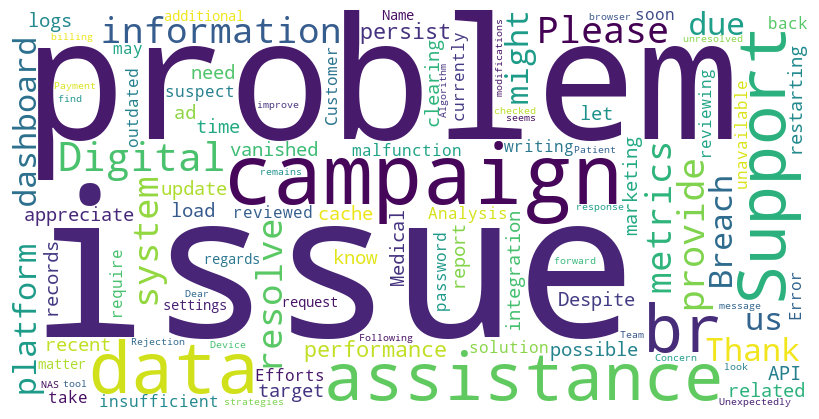

```python
# texto problem
texto_problem = " ".join(problem_errors)

# Nube de palabras problem
wordcloud = WordCloud(width = 800, height = 400,
                background_color ='white',
                stopwords = None,
                min_font_size = 10).generate(texto_problem)

plt.figure(figsize = (8, 8), facecolor = None)
plt.imshow(wordcloud)
plt.axis("off")
plt.tight_layout(pad = 0)
plt.show()
```

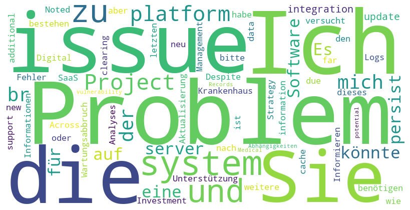

```python
#texto incident
texto_incident = " ".join(incident_errors)

# Nube de palabras incident
wordcloud = WordCloud(width = 800, height = 400,
                background_color ='white',
                stopwords = None,
                min_font_size = 10).generate(texto_incident)

plt.figure(figsize = (8, 8), facecolor = None)
plt.imshow(wordcloud)
plt.axis("off")
plt.tight_layout(pad = 0)
plt.show()
```

Cada nube de palabras muestra que tanto se repite una palabra dentro del conjunto de mensajes de error para cada clase, Problem e Incident. En ambos grupos se observan palabras recurrentes, como principalmente problem e issue, y otras que coinciden y que tienen un poco menos de repeticiones como system y platform. También se observa que la nube de palabras de Incident hay menos diversidad en las palabras que se repiten y resaltan palabras en Aleman, mientras que en la nube de Problem hay mayor diversidad.

Es importante recordar que en la exploración de datos se habia identificado este problema de coincidencia de palabras entre la clase Problem e Incident. Unas de estas palabras que se identificaron como más frecuentes en el dataset fueron Problem e Issue, y en esta nueva exploración de mensajes mal clasificados vuelven aparecer como las más recurrentes.

Con esto, se podría decir que quizás aspectos como el idioma y palabras similares son las que estén ocasionando la confusión en el clasificador. Además, la variabilidad de palabras podría estar llevando al clasificador a no identificar patrones claros para el caso de Problem. Es importante observar las fronteras de decisión y la clara discriminación de los grupos, para ver si quizás hay algún solapamiento.

d. Visualiza la estructura del espacio generado por el modelo de clasificación. Para ello, puedes aplicar una técnica de reducción de dimensionalidad (por ejemplo, kernel PCA o t-SNE) y generar una figura que marque los mensajes clasificados correctamente e incorrectamente. Enumera las pruebas que has realizado y comenta si es posible representar la frontera de decisión en un espacio 2D.

Para aplicar kernelPCA primero hay que definir el número de componentes principales a usar, sin embargo, con KernelPCA no se utiliza la varianza explicada como en PCA tradicional, ya que KernelPCA se basa en una matriz de similitud y no en las características originales de los datos. Para este caso se puede hacer un análisis de los autovalores obtenidos a partir de la matriz de kernel, los cuales reflejan esa importancia de cada componente en el espacio transformado. La magnitud de los autovalores puede ayudar a la selección del número de componentes, debido a que estos corresponden a la cantidad de "información" explicada en el espacio proyectado por cada componente.

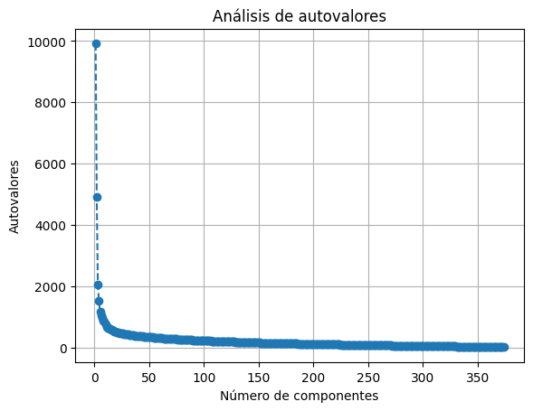

```python
from sklearn.decomposition import KernelPCA

kernel_pca = KernelPCA(kernel='precomputed', n_components=None,  random_state=1202)
kernel_pca.fit_transform(matriz_kernel_n[500])

# autovalores
eigenvalues = kernel_pca.eigenvalues_

# Graficar los autovalores
plt.plot(range(1, len(eigenvalues) + 1), eigenvalues, marker='o', linestyle='--')
plt.xlabel('Número de componentes')
plt.ylabel('Autovalores')
plt.title('Análisis de autovalores')
plt.grid(True)
plt.show()
```

La gráfica muestra magnitudes bastante altas para las primeras componentes, indicando una captura de gran parte de variabilidad de los datos en esos espacios reducidos, indicando la relevancia de esos componentes para describir relaciones no lineales entre las características originales de los datos. A medida que va aumentan la cantidad de componentes, se va reduciendo la magnitud de los autovalores, indicando poca relevancia en cuanto a la captura de la variabilidad de los datos. Es decir, que a medida que se aumentan mucho las dimensiones no se aporta mucha información adicional sobre los datos. El número optimo de componentes es donde los autovalores empiezan a ser pequeños y no hay cambios significativos en el aumento de componentes.

En la gráfica ese punto de inflexión se da en componentes bastante altos, lo cual sugiere que el modelo tiene una estructura compleja. Se observa que en el tercer autovalor la magnitud continúa siendo aun bastante alta, y ya se ve una reducción significativa en aproximadamente 10 componentes. Esto podría ser un indicio de la dificultad del problema para representar fronteras de decisión en bajas dimensiones y del comportamiento no lineal de los datos.

Primero representemos el grafico en 2D para ver la estructura del espacio generado solo con las 2 primeras componentes.

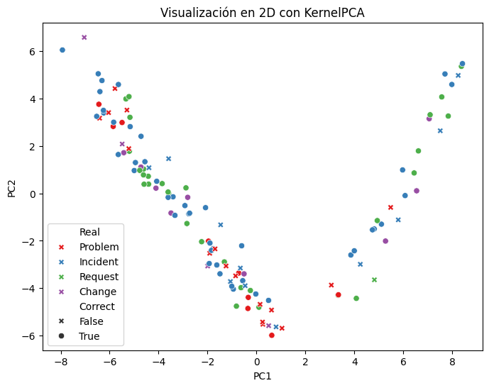

```python
# KernelPCA con kernel precomputado para reducir la dimensionalidad a 2D
kernel_pca = KernelPCA(n_components=2, kernel='precomputed', random_state=1202)

# matriz kernel precomputada para los datos de entrenamiento y prueba
X_train_2D = kernel_pca.fit_transform(matriz_kernel_n[500])  # kernel train
X_test_2D = kernel_pca.transform(matriz_kernel_t_n[500])  # kernel test

#DataFrame para la visualización
df_plot = pd.DataFrame({
    'PC1': X_test_2D[:, 0],
    'PC2': X_test_2D[:, 1],
    'Real': muestras_n[500]['y_test'],
    'Predict': muestras_n[500]['y_pred']
})
df_plot['Correct'] = df_plot['Real'] == df_plot['Predict']

plt.figure(figsize=(8, 6))
sns.scatterplot(data=df_plot, x='PC1', y='PC2', hue='Real', style='Correct', palette='Set1', markers={True: 'o', False: 'X'})
plt.title("Visualización en 2D con KernelPCA")
plt.legend(loc='best')
plt.show()
```

Los resultados muestran una separación principalmente en dos grupos, donde dentro de cada uno se encuentran valores reales y predichos para cada clase; sin embargo, la separación en dos dimensiones no implica una separación completa de las clases. Esto sugiere que el kernel de trigramas está capturando de manera significativa las relaciones entre las clases, pero no alcanza a separar completamente las clases en una representación de baja dimensionalidad (2D).

Como se observó en los apartados anteriores, el kernel de trigramas parece ser capaz de capturar relaciones no lineales entre las clases. No obstante, la visualización en 2D no refleja completamente las separaciones. En un espacio de mayor dimensión las clases podrían ser más fácilmente separables.

Además, recordemos que en la gráfica de autovalores, se observó que la magnitud de los autovalores es alta en las primeras dimensiones, lo que confirma que el modelo captura una gran parte de la variabilidad en las primeras componentes. A partir de aproximadamente 10 componentes, se observa una reducción significativa en esta captura de variabilidad. Esta refuerza la idea de que la separación de clases en un espacio de baja dimensionalidad es difícil, lo que indica la complejidad no lineal de los datos. Con esto se tiene que, las clases no se separan completamente en 2D, lo que sugiere que el modelo está lidiando con patrones complejos que no se pueden capturar adecuadamente con una reducción de la dimensionalidad a solo dos componentes, es decir que, no es posible representar la frontera de decisión en un espacio 2D.

Revisemos dos componentes con T-SNE:

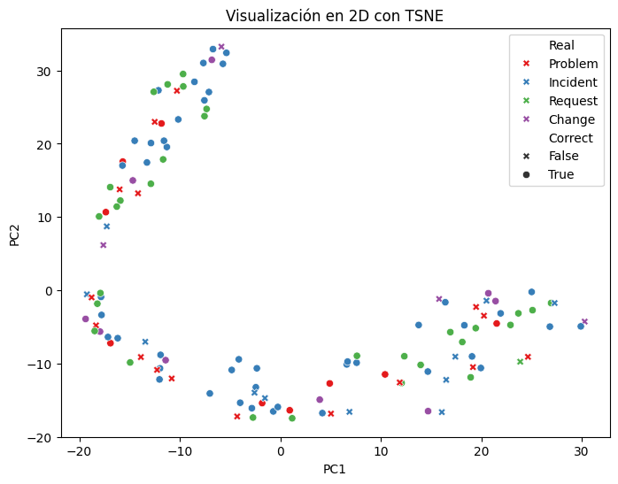

```python
# TNSE con kernel precomputado para reducir la dimensionalidad a 2D
tsne = TSNE(n_components=2, random_state=1202)

# train y test
matriz_kernel_all = np.concatenate([matriz_kernel_n[500], matriz_kernel_t_n[500]], axis=0)

# matriz kernel precomputada para los datos de entrenamiento y prueba
X_all_2D = tsne.fit_transform(matriz_kernel_all)

#separación de los datos
X_train_2D = X_all_2D[len(muestras_n[500]['y_test']):, :]
X_test_2D = X_all_2D[:len(muestras_n[500]['y_test']), :]

#DataFrame para la visualización
df_plot = pd.DataFrame({
    'PC1': X_test_2D[:, 0],
    'PC2': X_test_2D[:, 1],
    'Real': muestras_n[500]['y_test'],
    'Predict': muestras_n[500]['y_pred']
})

df_plot['Correct'] = df_plot['Real'] == df_plot['Predict']

plt.figure(figsize=(8, 6))
sns.scatterplot(data=df_plot, x='PC1', y='PC2', hue='Real', style='Correct', palette='Set1', markers={True: 'o', False: 'X'})
plt.title("Visualización en 2D con TSNE")
plt.legend(loc='best')
plt.show()
```

Los resultados no muestran una clara separación de las clases, lo cual confirma la dificultad de representar la frontera de decisión del clasificador en una baja dimensionalidad. Vemos que todas las clases, con sus predicciones correctas e incorrectas se encuentran mezcladas. Como se analizó con Kernel PCA, quizás en un espacio de mayor dimensión las clases podrían ser más fácilmente separables. Portal razon, se puede inferir que el problema es complejo y que la representación de la frontera de decisión en un espacio 2D no es viable debido a la naturaleza no lineal de los datos.

Revisemos ahora un gráfico de 3D con KernelPCA para identificar si con 3 componentes es posible separar los datos y observar las diferentes clases y su comportamiento.

```python
# KernelPCA con kernel precomputado para reducir la dimensionalidad a 3D
kernel_pca = KernelPCA(n_components=3, kernel='precomputed', random_state=1202)

# matriz kernel precomputada para los datos de entrenamiento y prueba
X_train_3D = kernel_pca.fit_transform(matriz_kernel_n[500])  # kernel train
X_test_3D = kernel_pca.transform(matriz_kernel_t_n[500])  # kernel test

# DataFrame para la visualización
df_plot = pd.DataFrame({
    'PC1': X_test_3D[:, 0],
    'PC2': X_test_3D[:, 1],
    'PC3': X_test_3D[:, 2],
    'Real': muestras_n[500]['y_test'],
    'Predict': muestras_n[500]['y_pred']
})
df_plot['Correct'] = df_plot['Real'] == df_plot['Predict']

#trazas para los puntos correctos (o) e incorrectos (X)
trace_correct = go.Scatter3d(x=df_plot[df_plot['Correct'] == True]['PC1'], y=df_plot[df_plot['Correct'] == True]['PC2'], z=df_plot[df_plot['Correct'] == True]['PC3'],
    mode='markers', marker=dict(size=6, color=df_plot[df_plot['Correct'] == True]['Real'].astype('category').cat.codes, colorscale='Viridis', opacity=0.8), name='Correct', marker_symbol='circle', showlegend=True)

trace_incorrect = go.Scatter3d(x=df_plot[df_plot['Correct'] == False]['PC1'], y=df_plot[df_plot['Correct'] == False]['PC2'], z=df_plot[df_plot['Correct'] == False]['PC3'],
    mode='markers', marker=dict(size=6, color=df_plot[df_plot['Correct'] == False]['Real'].astype('category').cat.codes, colorscale='Viridis', opacity=0.8), name='Incorrect', marker_symbol='x', showlegend=True)

# las 4 categorías
trace_classes = go.Scatter3d(x=df_plot['PC1'], y=df_plot['PC2'], z=df_plot['PC3'], mode='markers', marker=dict(size=6,
        color=df_plot['Real'].astype('category').cat.codes, colorscale='Viridis', opacity=0.8), name='Classes', showlegend=False)

# Combinar las trazas
fig = go.Figure(data=[trace_correct, trace_incorrect, trace_classes])

#Gráfico
fig.update_layout(title="Visualización 3D con KernelPCA",
                scene=dict(xaxis_title='PC1', yaxis_title='PC2', zaxis_title='PC3'),
                legend=dict(
                title='Clasificación',
                itemsizing='constant',
                tracegroupgap=10),
                showlegend=True)

fig.show()
```

[output not shown]

A pesar de tener una mejor visualización, aun es difícil establecer una frontera de decisión, donde se evidencia una clara clasificación de las clases. A partir de los resultados de la gráfica de autovalores, donde se observa que a mayor número de componentes los autovalores disminuyen, se puede inferir que, en un espacio de mayor dimensión, la separación de las clases se vuelve más clara y las fronteras de decisión no lineales pueden ser mejor representadas.

e. La SVM es un clasificador binario. Investiga y describe qué modalidad multiclase se usa en la implementación que has usado ("one-vs-all", "one-vs-one", etc.).

En la implementación de SVM utilizada (SVC de scikit-learn),el soporte multiclase por defecto se maneja mediante un esquema "one-vs-one", el cual consiste en ajustar un clasificador binario por cada par de clases. El número de clasificadores depende del número de clases, donde un conjunto de k clases genera k(k−1)/2 problemas de clasificación binaria, y la clase final se predice según el mayor número de votos recibidos entre estos clasificadores binarios.

Por su parte el esquema "one-vs-all" transforma el problema multiclase en varios problemas binarios, donde cada clasificador se entrena para distinguir si una muestra pertenece o no a una clase específica. Esto genera un clasificador binario para cada clase

"one-vs-one" requiere ajustar más clasificadores y trabaja con más conjuntos de datos, haciendolo un método más lento que "one-vs-all"; sin embargo, puede ser ventajoso para algoritmos kernel, debido a que puede ser más efectivo para manejar interacciones complejas entre clases. Esto se debe a que cada clasificador individual en "one-vs-one" solo involucra un pequeño subconjunto de los datos (un par de clases a la vez), mientras que en "one-vs-all" el clasificador debe manejar el conjunto de datos completo en cada uno de sus problemas binarios (más lento en problemas con muchas clases).

Fuente:

https://scikit-learn.org/stable/modules/generated/sklearn.svm.SVC.html https://scikit-learn.org/stable/modules/generated/sklearn.multiclass.OneVsOneClassifier.html https://machinelearningmastery.com/one-vs-rest-and-one-vs-one-for-multi-class-classification/

f. Opcional: Usa otro método de clasificación (p.ej. Random Forests, XGBoost, etc.) y compara sus resultados con la SVM, tanto en precisión como en tiempo de ejecución.

Se usará otro método de clasificación como Random Forests para comprar los resultados obtenidos con respecto a SVM. Se comparará la precisión (accuracy) y el tiempo de ejecución (coste computacional). Para esto, primero se debe identificar el número óptimo de árboles. Para este ejercicio se implementará el max_features que trae scikit-learn por defecto para problemas de clasificación que es sqrt(n_features). El número optimo de árboles se identifica a través del entrenamiento de múltiples árboles y el cálculo del error (OOB):

[output not shown]

```
Número de árboles: 10 Error OOB: 0.528
Número de árboles: 60 Error OOB: 0.44799999999999995
Número de árboles: 110 Error OOB: 0.42400000000000004
Número de árboles: 160 Error OOB: 0.41866666666666663
Número de árboles: 210 Error OOB: 0.42933333333333334
Número de árboles: 260 Error OOB: 0.42400000000000004
Número de árboles: 310 Error OOB: 0.42400000000000004
Número de árboles: 360 Error OOB: 0.43200000000000005
Número de árboles: 410 Error OOB: 0.42400000000000004
Número de árboles: 460 Error OOB: 0.42666666666666664
Número de árboles: 510 Error OOB: 0.42666666666666664
Número de árboles: 560 Error OOB: 0.43200000000000005
Número de árboles: 610 Error OOB: 0.43466666666666665
Número de árboles: 660 Error OOB: 0.42400000000000004
Número de árboles: 710 Error OOB: 0.42400000000000004
Número de árboles: 760 Error OOB: 0.42933333333333334
Número de árboles: 810 Error OOB: 0.43466666666666665
Número de árboles: 860 Error OOB: 0.43466666666666665
Número de árboles: 910 Error OOB: 0.42933333333333334
Número de árboles: 960 Error OOB: 0.42933333333333334
```

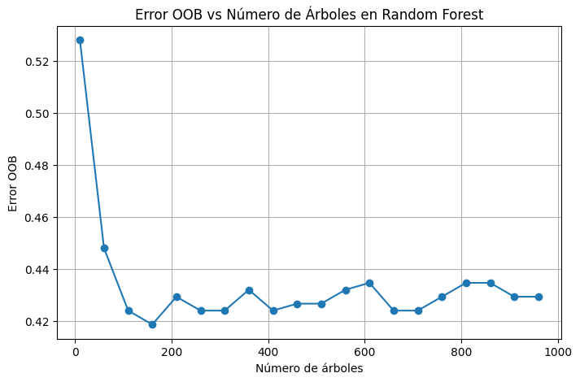

```python
# Lista de valores de ntree a evaluar
n_trees = np.arange(10, 1001, 50)
oob_errors = []

# Entrenar modelos con diferentes valores de ntree
for n in n_trees:
    rf = RandomForestClassifier(n_estimators=n, oob_score=True, random_state=213, bootstrap=True)
    rf.fit(matriz_kernel_n[500], muestras_n[500]['y_train'])
    oob_errors.append(1 - rf.oob_score_)
    print('Número de árboles:', n, 'Error OOB:', 1 - rf.oob_score_)

# Graficar el error OOB
plt.figure(figsize=(8,5))
plt.plot(n_trees, oob_errors, marker='o', linestyle='-')
plt.xlabel("Número de árboles")
plt.ylabel("Error OOB")
plt.title("Error OOB vs Número de Árboles en Random Forest")
plt.grid(True)
plt.show()
```

Teniendo en cuenta los resultados obtenidos, el número óptimo de árboles para configurar el modelo de Random Forest sería 100, ya que es el punto donde el error se estabiliza. A partir de ese número, el aumento en la cantidad de árboles no mejora significativamente el rendimiento del modelo.

Una vez que determinamos este parámetro, entrenamos el modelo con esta configuración, midiendo tanto el tiempo de entrenamiento como la precisión del modelo.

Es importante resaltar que, en este caso, Random Forest puede ser entrenado directamente con una matriz de similitudes, en lugar de trabajar con las características explícitas de las muestras (como lo haría en problemas tradicionales de clasificación). Esto es posible porque Random Forest utiliza la matriz de similitudes para identificar patrones y relaciones entre las muestras, lo que le permite dividir eficientemente el conjunto de datos en función de esas similitudes y realizar la clasificación.

```python
# tiempo de ejecución
start_time_rf = time.time()

# Entrenamiento de Random Forest
rf_model = RandomForestClassifier(n_estimators=100, random_state=1202, oob_score=True, bootstrap=True)
rf_model.fit(matriz_kernel_n[500], muestras_n[500]['y_train'])

# Predicción y evaluación de la precisión
y_pred_rf = rf_model.predict(matriz_kernel_t_n[500])
accuracy_rf = accuracy_score(muestras_n[500]['y_test'], y_pred_rf)

# Medir el tiempo de ejecución
execution_time_rf = time.time() - start_time_rf

print("Precisión de Random Forest:", accuracy_rf)
print("Tiempo de ejecución de Random Forest: {:.4f} segundos".format(execution_time_rf))
```

```
Precisión de Random Forest: 0.68
Tiempo de ejecución de Random Forest: 0.5968 segundos
```

Los resultados obtenidos muestran que el accuracy global de Random Forest es inferior al observado en el modelo entrenado con el kernel precomputado, que fue de 0.74. En este caso, Random Forest alcanzó un accuracy menor, lo que indica que el modelo basado en kernel ha logrado una clasificación más precisa.

Sin embargo, cuando analizamos el coste computacional, los resultados son diferentes. El modelo de Random Forest tuvo un tiempo de ejecución de 0.59 segundos, mucho más rápido en comparación con el modelo SVM con kernel precomputado, que tomó aproximadamente 20 segundos. Este resultado sugiere que, aunque el modelo con kernel ofrece una mejor precisión, su coste computacional es considerablemente mayor.

Es importante analizar otras métricas de evaluación además de la precisión global, como las que se muestran a continuación:

```python
# reporte de clasifciación de Random Forest
print(classification_report(muestras_n[500]['y_test'], y_pred_rf))
```

```
              precision    recall  f1-score   support

      Change       0.60      0.23      0.33        13
    Incident       0.69      0.88      0.77        56
     Problem       0.30      0.12      0.17        25
     Request       0.77      0.97      0.86        31

    accuracy                           0.68       125
   macro avg       0.59      0.55      0.53       125
weighted avg       0.62      0.68      0.63       125
```

En términos generales, el modelo Random Forest presenta dificultades para clasificar correctamente las clases, con métricas individuales inferiores a las observadas en el modelo basado en kernel. Por ejemplo, la clase Problem tiene una precisión, un recall y f1-score bastante bajos; y la clase Change muestra una caída considerable en todas sus métricas con respecto a lo obtenido con Kernel. Estos resultados están alineados con la observación del accuracy global, sugiriendo que Random Forest tiene problemas para predecir con precisión ciertos tipos de mensajes. Un análisis más detallado de la matriz de confusión y los mensajes de error podría proporcionar más información sobre las razones de estas dificultades y cómo mejorar el modelo; sin embargo, con estos resultados parciales y en este problema particular, podríamos decir que es mejor considerar el modelo con Kernel pese al coste computacional.